# The bdpar Package: Big Data Pipelining Architecture for R

### 3.2 Developing new functionalities

As previously stated, the design of the software architecture of *bdpar* is focused on facilitating the customization of any stage of the process (data loader and pipeline executor). Specifically, *bdpar* allows users to: (i) defining new types of input data parses, (ii) creating new pipes, and (iii) implementing and deploying new preprocessing tasks.

Regarding the first aspect, the development of new content parsers involves two stages: (i) the implementation of a customized extractor by overriding solely the methods of the `Instance` class that are necessary to load the input and (ii) the registration of the created extractor so it can be loaded by the *bdpar* framework. Two code fragments to detail the development and registration of a new customized parsers is included below.

```r
ExtractorImage <- R6::R6Class(
  classname = "ExtractorImage",
  inherit = Instance,
  public = list(
    initialize = function(path) {
      super$initialize(path)
    },
    obtainSource = function() {
      source <- imager::load.image(super$getPath())
      super$setSource(source)
      super$setData(source)
    } ) )
```

a) Implementation of new `ExtractorImage` parser.

```r
extractors <- ExtractorFactory$new()
extractors$registerExtractor(extension= c("jpeg","png"),
                             extractor= ExtractorImage)
```

b) Dynamic extractor registration operation in *bdpar*.

As can be seen, the first code snippet describes the formal structure of a new extractor. Particularly, `ExtractorImage` is able to load an image into an Instance object. To accomplish this task, the `obtainSource` method loads (by invoking `load.image()` method) an image from the file path received as a parameter of the class constructor (`super$getPath()`). Then, the loaded image is stored in the source variable of the `Instance` superclass (by invoking `super$setSource()` method) and is assigned to the data variable by calling to `super$setData()` method. The data field is used to store the result of each task comprising the pipeline.

Moreover, the second fragment of code exemplifies the registration of the previously created extractor in *bdpar* framework. As can be depicted, this operation is performed by a simple call to the `registerExtractor` method included in `ExtractorFactory` class. Due to the one-to-one dependency between each extractor and the different input formats, *bdpar* requires the definition of a specific extension (or set of extensions) to discern which type of extractor should execute. Also, `ExtractorFactory` provides two additional methods (i) `getAllExtractors`, which shows all registered extractors in *bdpar* framework and (ii) `removeExtractor`, which deletes a specific data extractor. Finally, to avoid parsing errors, unsupported input contents by registered extractors are automatically ignored by *bdpar*.

```r
Image2Pipe <- R6::R6Class(
  name = "Image2Pipe",
  inherit = GenericPipe,
  public = list(
    initialize = function(propertyName= "",
                          alwaysBeforeDeps= list(),
                          notAfterDeps= list()) {
            super$initialize(propertyName, alwaysBeforeDeps, notAfterDeps)
    },
    pipe = function(instance) {
      instance$obtainSource()
      instance
    } ) )

ImageCroppingPipe <- R6::R6Class(
  "ImageCroppingPipe",
  inherit = GenericPipe,
  public = list(
    initialize = function(propertyName= "",
                          alwaysBeforeDeps= list("Image2Pipe"),
                          notAfterDeps= list()) {
            super$initialize(propertyName, alwaysBeforeDeps, notAfterDeps)
    },
    pipe = function(instance) {
    data <- instance$getData()
    data <- imager::imsub(data, x > height/2)
    instance$setData(data)
      instance
    } ) )

ImageResizePipe <- R6::R6Class(
  "ImageResizePipe",
  inherit = GenericPipe,
  public = list(
    initialize = function(propertyName= "",
                          alwaysBeforeDeps= list("Image2Pipe"),
                          notAfterDeps= list()) {
            super$initialize(propertyName, alwaysBeforeDeps, notAfterDeps)
    },
    pipe = function(instance) {
    data <- instance$getData()
    data <- imager::imrotate(data, 30)
    instance$setData(data)
      instance
    } ) )
```

As can be seen, the `Image2Pipe` class stores the loaded image into a new instance. Following, `ImageCroppingPipe` and `ImageResizePipe` class apply different image manipulation functions (`imager::imsub`, `imager::imrotate`) to halve and rotate the images, respectively. Following the result, of each pipe is stored into a specific field of the `Instance` object (by calling the `instance$setData()` method). To ensure proper operation of both tasks, image content should be previously loaded into an instance object (by invoking `Image2Pipe` associated task). To this end, a priori dependence with `Image2Pipe` has been defined in the `initialize` method of both pipes. As mentioned before, to facilitate the development and execution of pipes, dependencies between pipes are automatically managed by the object-oriented pipe operator (%>|%). Finally, in order to develop robust pipelines, `instance` objects should be invalidated when an error occurs, or the requirements are not satisfied (such as the storage of empty data or non-identification of textual language).

Finally, *bdpar* allows users to customize existing pipelines and develop new ones from scratch. In order to motivate the usage of *bdpar* regardless of user programming skills, the framework allows to manually or dynamically design new pipelines. The first method requires the creation of a new class (inheriting from `GenericPipeline`) which implements the `execute` method defined in the parent class. Moreover, to ensure proper management of (possible) execution errors (such as invalidated instances), a try-catch function should be included. Additionally, *bdpar* allows customizing the log messages (if needed) by calling the `bdpar.log()` function. Below we include an example showing how a customized pipeline is manually created.

```r
TestPipeline <- R6::R6Class(
  classname = "TestPipeline",
  inherit = GenericPipeline,
  public = list(
    initialize = function() {},
    execute = function(instance) {
      message("[TestPipeline][execute][Info] ", instance$getPath())
      tryCatch(
         instance %>|% Image2Pipe$new() %>|%
             ImageCroppingPipe$new() %>|% ImageResizePipe$new(),
          error = function(e) {
               bdpar.log(message = paste0(instance$getPath()," :", paste(e)),
                 level= "ERROR",
                 className= class(self)[1],
                 methodName= "execute")
                 instance$invalidate()
        } )
      return(instance)
    } ) )
```

On the other hand, the dynamic method allows the creation of custom pipelines by simply indicating a list containing the pipe objects to be used. To achieve a higher level of flexibility dynamic, the model provides two ways of defining pipelines: (i) during the object instantiation or (ii) by calling the `add` function. A simple example describing how the previous pipeline is created following the dynamic method is included below.

```r
pipeline <- DynamicPipeline$new(pipeline= list(Image2Pipe$new(),
                                               ImageCroppingPipe$new(),
                                               ImageResizePipe$new()))
```

a) Pipeline definition during object instantiation.

```r
pipeline <- DynamicPipeline$new()
pipeline$add(list(Image2Pipe$new(), ImageCroppingPipe$new(),
                  ImageResizePipe$new()))
```

b) Pipeline creation using the add method.

Additionally, the dynamic method provides six methods able to extend the pipeline customization capabilities: (i) `add(pipe, pos=NULL)`, which adds new pipe object(s) to the pipeline flow at a certain position (or at the end if not defined), (ii) `removeByPos(pos)`, which removes a pipe object at a given position, (iii) `removeByPipe(pipe.name)` responsible for erasing a `pipe` object by name, (iv) `removeAll()` capable of releasing all pipe objects from the pipeline, (v) `get()` returning a list containing the pipe objects comprising the pipeline, and finally, (vi) `print()` which displays the pipes comprised in the pipeline.

As can be realized from both methods, the manual definition of pipelines allows users to have greater control and insight over the pipeline (such as personalizing error-handling methods or the inclusion of new user-defined object-oriented pipeline operators). Conversely, the dynamic mode enables users to define optimal pipelines without expert knowledge of `R6` and OOP concepts.

### 3.3 Managing *bdpar* configuration options

`bdpar.Options` included in *bdpar* allows managing configuration parameters to customize the behavior of available tasks and indicate parameters needed for the proper operation of pipes and/or content extractors (such as path locations for slang dictionaries or credentials required by Twitter or Youtube APIs, respectively). Moreover, to easily search and access the configuration, `bdpar.Options` stores parameters following a key-value pair structure. As can be deducted, the key parameter is used to uniquely identify a configuration entry. In order to facilitate the management of configuration parameters, `bdpar.Options` provides four main methods: (i) `bdpar.Options$add(key, value)`, which adds a new configuration entry, (ii) `bdpar.Options$set(key, value)` used to modify the value of an existing configuration parameter, (iii) `bdpar.Options$remove(key)`, which removes an entry matching a specific name, and finally, (iv) `bdpar.Options$reset()` used to restore `bdpar.Options` to its initial state (default options). Table 2 describes the configuration options included in *bdpar*.

Table 2: Structure of *bdpar* configuration options.

| Type | Key | Assigned by default | Description |
| --- | --- | --- | --- |
| API credentials | twitter.consumer.key | x | Set of keys need to connect to Twitter and Youtube API |
|  | twitter.consumer.secret | x |  |
|  | twitter.access.token | x |  |
|  | twitter.access.token.secret | x |  |
|  | youtube.app.id | x |  |
|  | youtube.app.password | x |  |
| API cache | cache.youtube.path | x | Path to temporary place extracted data |
|  | cache.twitter.path | x |  |
| Pipe parameters | teeCSVPipe.output.path | $\surd$ | Defines the out-put file path for `TeeCSVPipe` |
| Extractor options | extractorEML.mpaPartSelected | $\surd$ | Indicates the content-type to parse on multi-part emails |
| N-RE handler | cache.folder | $\surd$ | Indicates the path to store the intermediate results |
| Parallel settings | numCores | $\surd$ | Selects the number of cores used to execute the pipelines |
| Resource files | resources.abbreviations.path | $\surd$ | Location for the different language dictionaries (slang, contractions, $\ldots$) |
|  | resources.contractions.path | $\surd$ |  |
|  | resources.interjections.path | $\surd$ |  |
|  | resources.slangs.path | $\surd$ |  |
|  | resources.stopwords.path |  |  |

As can be seen from Table 2, configuration options are divided into seven categories: (i) API credentials, (ii) API cache, (iii) pipe parameters (iv) Extractor options, (v) instance cache handler, (vi) parallel settings, and (vii) resource files. It is important to take into account that values for API credentials are not provided by default due to the inexistence of publicly available access keys for both Youtube and Twitter (only for private use with prior approval). Following, the optional API cache configuration entries are responsible for designating temporal locations to store information obtained after executing the content extractors. Defining cache paths API ensures that duplicated sources are executed only once (avoids parsing duplicated inputs).

Moreover, pipe parameters and extractor options allow specifying configuration values needed to guarantee the proper execution of pipes and extractors, respectively. Particularly, default "extractorEML.mpaPartSelected" entry allows defining which content-type (text/plain or text/html) should be extracted in multipart emails while "teeCSVPipe.output.path" indicates the location to store the CSV file generated by `TeeCSVPipe` pipe.

In addition, the not-re-execution handler allows defining the path to store the information required for the proper operation of the not-re-execution functionality. Despite this, the feature is very useful to reduce both unnecessary computation costs and time consumption that requires extra storage space. Therefore, *bdpar* allows the deletion of the intermediate results by invoking the specific `bdpar.Options$cleanCache()` method.

Following, parallel settings category is used to define the configuration values to handle parallelization in *bdpar*. Concretely, "numCores" entry allows defining the number of CPU cores to be used when a pipeline is executed. By default, *bdpar* is configured following a sequential paradigm (`numCores = 1`). Additionally, to ensure proper use of CPU resources *bdpar* provides a mechanism to verify whether the number of assigned CPU cores is compatible with the hardware specifications or not. If the assigned CPU cores are not valid, *bdpar* will be executed using the most optimal configuration according to the hardware specifications.

The last category comprises different dictionaries needed to perform multiple language-dependent operations (such as contraction detection or stopwords removal). Dictionaries provided by default ensure the compatibility of *bdpar* from 8 to 50 different languages (depending on the text-mining operation selected).

## 4 A case study

In order to illustrate the functionality of the *bdpar* package from a more realistic perspective, we developed a case study to show the most frequent words from a heterogeneous dataset collection (containing SMS and emails). The dataset comprises 20 emails (eml format) and 20 SMS in plain text from the nutritional and health domain. Moreover, to ensure straightforward reproducibility, (i) all the resources used are included in the package, and the pipeline provided by the package (`DefaultPipeline`) was selected to perform the content preprocessing flow, and (ii) resulting dataset was stored into a structured CSV file. Once the pipeline was executed, 18 new columns were generated from the outputs acquired after executing some pipeline tasks (labeled according to the property names described in Table 1). For instance, the execution of `FindEmojiPipe` forces the creation (if not exists) of a new column (named "emojis") containing the emojis found for each instance (or blank if not found).

To carry out the case of study, word frequencies were computed over the text content generated after executing the whole pipeline tasks (stored in the data column). Additionally, some previous text-cleaning operations were performed over the preprocessed text prior to executing the computation of the word frequencies (using word-cloud plots). Concretely, words were reduced to their stem form (stemDocument), punctuation marks were deleted, and numbers were removed (using the [*tm*](https://CRAN.R-project.org/package=tm) package (Feinerer et al. 2008)). Finally, for comparison purposes, frequencies were calculated both individually and jointly (see Figures 2 and 3)

```r
#Execute bdpar framework
bdpar::runPipeline(path= system.file(“example”, package= “bdpar”),
                   cache= FALSE)
#Load CSV generated after executing bdpar
dataset <- read.csv(file= bdpar.Options$get("teeCSVPipe.output.path"),
                    sep= ";", stringsAsFactors= FALSE )

#Separate instances by type
sms <- dataset[dataset$extension == "tsms", ]
eml <- dataset[dataset$extension == "eml", ]
# Function to clean text and compute frequencies
word.frec <- function(data) {
  corpus <- tm::VCorpus(VectorSource(data))
  corpus <- tm::tm_map(corpus, removePunctuation)
  corpus <- tm::tm_map(corpus, removeNumbers)
  corpus <- tm::tm_map(corpus, stemDocument)
  sorted <- sort(rowSums(as.matrix(tm::TermDocumentMatrix(corpus))),
                 decreasing = TRUE)
  return(data.frame(word = names(sorted), freq = sorted))
}
sms.words <- word.frec(sms$data)
eml.words <- word.frec(eml$data)
all.words <- word.frec(dataset$data)
# Wordcloud for sms and emails
par(mfrow=c(1,2))
wordcloud::wordcloud(words= sms.words$word, freq= sms.words$freq,
                     min.freq= 1, max.words= 100, random.order= FALSE,
                     rot.per= .5, colors= RColorBrewer::brewer.pal(8, "Dark2"))
wordcloud::wordcloud(words= eml.words$word, freq= eml.words$freq,
                     min.freq= 1, max.words= 100, random.order= FALSE,
                     rot.per= .5, colors= RColorBrewer::brewer.pal(8, "Dark2"))
par(mfrow=c(1,1))
#Wordcloud for all instances (sms and email)
wordcloud::wordcloud(words= dataset.words$word, freq= all.words$freq,
                     min.freq= 1, max.words= 100, random.order= FALSE,
                     rot.per= .5, colors= RColorBrewer::brewer.pal(8, "Dark2"))
```

Figure 2 graphically represents the results achieved after performing an individualized analysis of each dataset (SMS and emails). Conversely, Figure 3 represents the frequencies achieved when analyzing both datasets together. Observing Figure 2, we see that frequencies of words included in SMS messages are lower than those included in emails. This is mainly due to the limited length of SMS messages (up to 160 characters). Therefore, the word frequency in Figure 3 has increased considerably, mainly owing to the joint evaluation of both datasets.

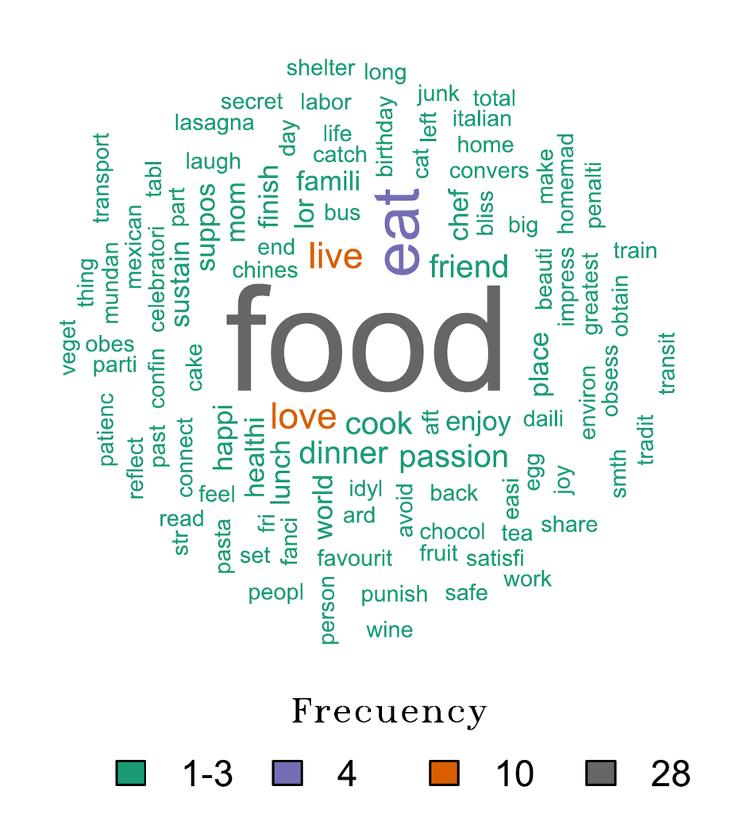

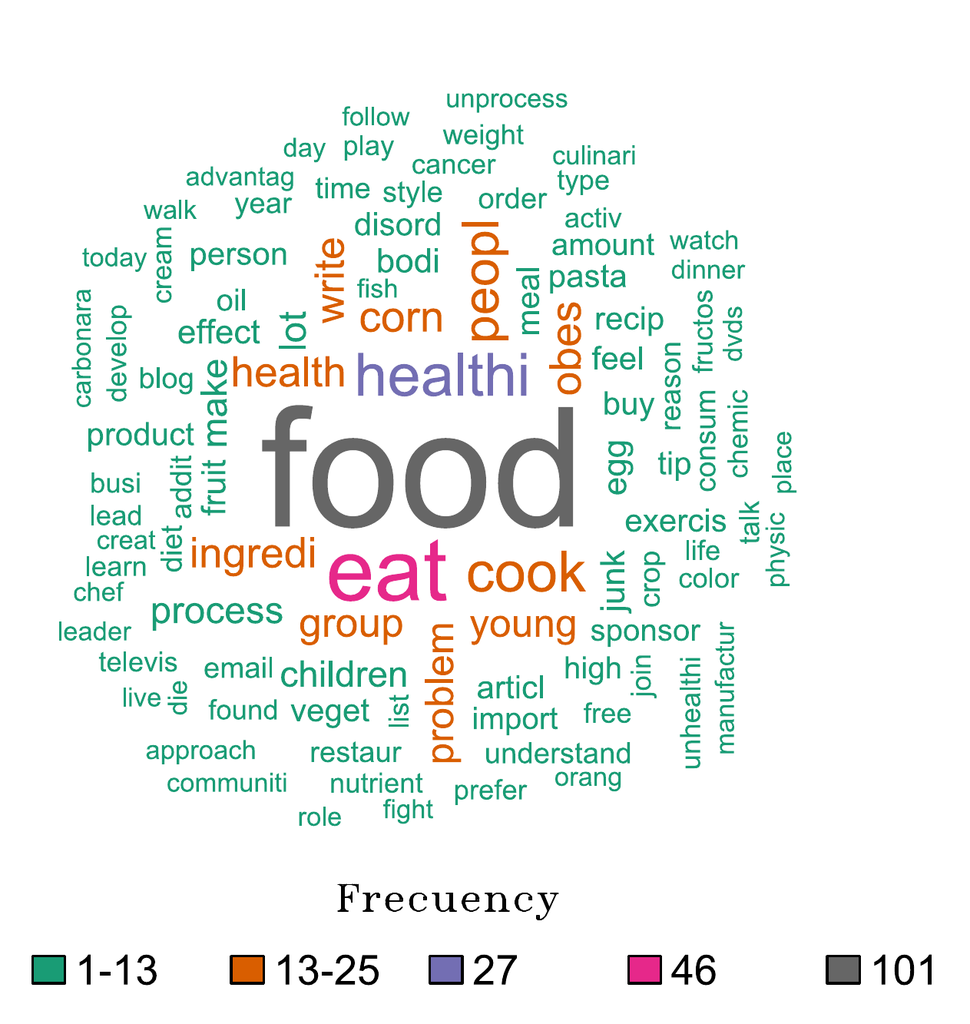

Figure 2: Wordcloud for SMS (left) and email (right).

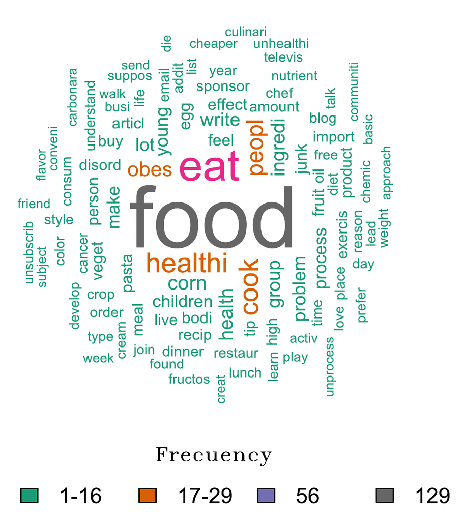

Figure 3: Wordcloud for SMS and email jointly.

Keeping in mind the functionality provided by *bdpar* (demonstrated through the current case study), it is easy to deduce that the application of data mining techniques over unstructured data could be easily addressed by taking advantage of the functionality of our framework. Some big data operations that could be addressed by taking advantage of *bdpar* are the clustering of documents using token features, the classification of documents, or the retrieval of documents for specific queries.

## 5 Conclusions and future work

In this work, we introduced *bdpar*, a pipe-based R framework to facilitate the creation of unified datasets from heterogeneous sources. Our framework allows users to (i) define new content extractors (data parsers), (ii) develop and deploy new preprocessing tasks (pipes), and (iii) define and build customized interconnected task flows (pipelines). Additionally, to save computational resources and increase execution speed, *bdpar* provides an optimized pipe operator (noted as `%>I%`) capable of aborting the processing of an instance if an error was detected. Finally, a case study was developed to demonstrate the capability of the framework to preprocess and unify heterogeneous data into a single CSV file.

## 6 Acknowledgements

The work of Tomás R. Cotos-Yáñez has been partially supported by the projects IN2017-84658-C2-1-R and PID2020-118101GB-I00 of the Spanish Ministry of Industry. David Ruano-Ordás has been supported by a post-doctoral fellowship from Xunta de Galicia (POSB-2021/024). Additionally, the work of José R. Méndez was partially funded by the project Semantic Knowledge Integration for Content-Based Spam Filtering (TIN2017-84658-C2-1-R) from the Spanish Ministry of Economy, Industry, and Competitiveness (SMEIC), State Research Agency (SRA) and the European Regional Development Fund (ERDF). SING group thanks CITI (Centro de Investigación, Transferencia e Innovación) from the University of Vigo for hosting its IT infrastructure. Finally, we thank the reviewers for their deep appropriate suggestions to improve the quality of the manuscript.

### 6.1 Supplementary materials

Supplementary materials are available in addition to this article. It can be downloaded at RJ-2021-065.zip

### 6.2 CRAN packages used

R6, repo, drake, magrittr, rtweet, tuber, tm

### 6.3 CRAN Task Views implied by cited packages

Databases, HighPerformanceComputing, NaturalLanguageProcessing, ReproducibleResearch

A. Amazon. AWS Amazon Data Pipeline. 2019. Accesed: 2019-05-6.

S. M. Bache and H. Wickham. *Magrittr: A forward-pipe operator for r.* 2020. URL https://CRAN.R-project.org/package=magrittr. R package version 2.0.1.

Brown, Brad, M. Chui and J. Manyika. Are you ready for the era of “big data.” *McKinsey Quarterly*, 4(1): 24–35, 2011.

W. Chang. *R6 and reference class performance tests.* 2019a. URL https://r6.r-lib.org/articles/Performance.html. R6 package version 2.4.1.

W. Chang. *R6: Encapsulated classes with reference semantics.* 2019b. URL https://CRAN.R-project.org/package=R6. R package version 2.4.0.

P. Di Tommaso. Awesome pipeline. *GitHub repository*, 2019.

Domo-Data. DOMO-data never sleeps 6.0. 2019. Accesed: 2019-04-05.

S. N. Dorogovtsev and J. F. F. Mendes. *Evolution of networks: From biological nets to the internet and WWW.* OUP Oxford, 2013. URL https://books.google.es/books?id=FFL1AgAAQBAJ.

N. A. of Engineering. *Cutting edge technologies.* Washington, DC: The National Academies Press, 1984. URL https://doi.org/10.17226/286.

I. Feinerer, K. Hornik and D. Meyer. Text mining infrastructure in R. *Journal of Statistical Software*, 25(5): 1–54, 2008. URL http://www.jstatsoft.org/v25/i05/.

Google. Google cloud dataflow. 2019. Accesed: 2019-05-6.

M. Iansiti and T. Khansa. Technological Evolution, System Architecture and the Obsolescence of Firm Capabilities. *Industrial and Corporate Change*, 4(2): 333–361, 1995. URL https://doi.org/10.1093/icc/4.2.333.

IBM. IBM Big Data Success Stories. 2019. Accesed: 2019-04-8.

IBM, P. Zikopoulos and C. Eaton. *Understanding big data: Analytics for enterprise class hadoop and streaming data.* 1st ed McGraw-Hill Osborne Media, 2011.

N. Kabeer. Introduction: The search for inclusive citizenship: Meanings and expressions in an interconnected world. 2005.

M. W. Kearney. *Rtweet: Collecting twitter data.* 2019. URL https://cran.r-project.org/package=rtweet. R package version 0.6.9.

A. Labrinidis and H. V. Jagadish. Challenges and opportunities with big data. *Proc. VLDB Endow.*, 5(12): 2032–2033, 2012. URL https://doi.org/10.14778/2367502.2367572.

W. M. Landau. The drake R package: A pipeline toolkit for reproducibility and high-performance computing. *Journal of Open Source Software*, 3(21): 2018. URL https://doi.org/10.21105/joss.00550.

J. Mervis. Agencies rally to tackle big data. *Science*, 336(6077): 22–22, 2012. URL https://doi.org/10.1093/10.1126/science.336.6077.22.

D. Miner and A. Shook. *MapReduce design patterns: Building effective algorithms and analytics for hadoop and other systems.* 1st ed O’Reilly Media, Inc., 2012.

F. Napolitano. *Repo: A data-centered data flow manager.* 2020. URL https://CRAN.R-project.org/package=repo. R package version 2.1.5.

P. O’Donovan, K. Leahy, K. Bruton and D. T. J. O’Sullivan. An industrial big data pipeline for data-driven analytics maintenance applications in large-scale smart manufacturing facilities. *Journal of Big Data*, 2(1): 25, 2015. URL https://doi.org/10.1186/s40537-015-0034-z.

B. Solutions. BDB Solutions for Big Data. 2019. Accesed: 2019-05-6.

G. Sood. *Tuber: Access YouTube from r.* 2019. URL https://CRAN.R-project.org/package=tuber. R package version 0.9.8.

VCloud. VCLOUD NEWS. 2019. Accesed: 2019-04-17.

H. Wickham. *Advanced r, second edition.* CRC Press, 2019. URL https://adv-r.hadley.nz/.

X. Wu, X. Zhu, G. Wu and W. Ding. Data mining with big data. *IEEE Transactions on Knowledge and Data Engineering*, 26(1): 97–107, 2014. URL https://doi.org/10.1109/TKDE.2013.109.